# Project Stage 2

Francis Surroca

2022-08-05

# Overview

[figure not shown]

Cover Image

In this final project, we will use R to evaluate logistic regression models with the objective of building a mortgage application approval/denial classifier. Of interest is modeling the probability that an applicant will be approved or denied as a function of observables to classify applicants as being likely to be approved or denied.

# A. Importing and Cleaning the Data

*“The variables in the dataset do not have intuitive names (e.g., the meaning of S3 is unclear). Referencing the data description and the AER paper, identify the qualitative dependent that you will be modeling and the set of co-variates that you intend to include in your various models, and rename the variables so that they have (somewhat) intuitive names. Be certain that the debt-to-income ratio and the race, self-employed, marital status, and education indicator variables are included, among other variables.”*

### 1. Load Datasets.

We downloaded the .csv file hmda.sw.csv from the GitHub repository and loaded it getting initial impressions of the data using the ‘head’ and ‘summary’ commands. Convert tibble to data.frame and remove all rows with NAs in them.

```r
applications <- read.csv("data\\hmda_sw.csv")
applications <- as.data.frame(applications)
head(applications)
```

```
##   seq s3 s4 s5  s6 s7   s9 s11 s13 s14 s15 s16 s17 s18 s19a s19b s19c s19d s20
## 1   2  1  1  1  88  1 1120   0   5   5   2   1  53   8 <NA>   NA   NA   NA   1
## 2   3  1  1  1 118  1 1120   0   5   5   1   2  51   8 <NA>   NA   NA   NA   1
## 3   7  1  1  1 185  1 1120   0   5   5   1   2  99   8 <NA>   NA   NA   NA   1
## 4   9  1  1  1 185  1 1120   0   5   5   1   2 110   1 <NA>   NA   NA   NA   1
## 5  10  1  1  1 330  1 1120   0   5   5   1   2 129   0 <NA>   NA   NA   NA   1
## 6  11  1  1  1  97  1 1120   0   5   5   1   2  65   1 <NA>   NA   NA   NA   1
##   s23a s24a s25a s26a s27a s30a s30c s31a s31c  s32 s33 s34 s35 s39 s40 s41 s42
## 1    M    0   19   19    0 1938 2000 2241 2000  939 110   0  30   0   0  34   2
## 2    U    0    3    1    0 2638 1642 2638 1642 1161 128   0  19   0   1  46   2
## 3    M    0   13   14    0 5000 2500 5600 2500 2011 196   0  24   0   1  24   2
## 4    M    2    3    3    0 7667    0 7667    0 1937 210   0  11   1   1  20   2
## 5    M    1   17   11    0 6083 4250 6083 4250 3608 550   0 222   1   1   6   1
## 6    M    0   10    2    0 5416    0 5416    0  940 190   0  26   1   1  15   1
##   s43 s44  s45  s46 s47 s48  s49 s50 s51 s52 s53 s54 s55 s56      s57 netw uria
## 1   5   0 22.1 22.1   3 360 <NA> 110   2   0   0   N   0   1 999999.4   92  3.9
## 2   2   0 26.5 26.5   2 360 <NA> 128   2   1   0   N   0   0 999999.4    3  3.2
## 3   1   0 24.8 37.2   2 360 <NA> 201   2   0   0   N   0   0 999999.4   22  3.2
## 4   1   0 25.0 32.0   2 360 <NA> 215   2   1   0   N   0   0      1.0  241  4.3
## 5   1   0 35.0 36.0   2 360 <NA> 550   2   0   0   N   0   0      2.0  365  3.2
## 6   1   0 17.0 24.0   2 360 <NA> 190   2   0   0   N   0   0      2.0  201  3.9
##   rtdum bd mi old vr school    chval dnotown dprop
## 1     0  1  1   1  0     15 206.7355       0     0
## 2     0  1  1   0  1     18 238.4943       0     0
## 3     0  1  1   1  0     12 200.1977       0     0
## 4     0  0  1   0  1     12 193.8895       0     0
## 5     0  0  1   1  0     20 257.0874       0     0
## 6     0  1  1   1  0     16 237.8392       0     0
```

```r
summary(applications)
```

```
##       seq             s3          s4          s5              s6
##  Min.   :   2   Min.   :1   Min.   :1   Min.   :1.000   Min.   :  2.0
##  1st Qu.:1180   1st Qu.:1   1st Qu.:1   1st Qu.:1.000   1st Qu.: 95.0
##  Median :2472   Median :1   Median :1   Median :1.000   Median :122.0
##  Mean   :2329   Mean   :1   Mean   :1   Mean   :1.037   Mean   :139.1
##  3rd Qu.:3352   3rd Qu.:1   3rd Qu.:1   3rd Qu.:1.000   3rd Qu.:158.0
##  Max.   :4509   Max.   :1   Max.   :1   Max.   :3.000   Max.   :980.0
##
##        s7              s9            s11              s13
##  Min.   :1.000   Min.   :1120   Min.   :0.0000   Min.   :3.000
##  1st Qu.:1.000   1st Qu.:1120   1st Qu.:0.0000   1st Qu.:5.000
##  Median :1.000   Median :1120   Median :0.0000   Median :5.000
##  Mean   :1.269   Mean   :1120   Mean   :0.1744   Mean   :4.715
##  3rd Qu.:1.000   3rd Qu.:1120   3rd Qu.:0.0000   3rd Qu.:5.000
##  Max.   :3.000   Max.   :1120   Max.   :1.0000   Max.   :5.000
##
##       s14             s15             s16             s17
##  Min.   :1.000   Min.   :1.000   Min.   :1.000   Min.   :     0
##  1st Qu.:5.000   1st Qu.:1.000   1st Qu.:2.000   1st Qu.:    45
##  Median :5.000   Median :1.000   Median :2.000   Median :    60
##  Mean   :5.703   Mean   :1.223   Mean   :2.513   Mean   : 13941
##  3rd Qu.:8.000   3rd Qu.:1.000   3rd Qu.:4.000   3rd Qu.:    86
##  Max.   :8.000   Max.   :3.000   Max.   :8.000   Max.   :999999
##  NA's   :1                       NA's   :1
##       s18            s19a                s19b            s19c
##  Min.   :0.000   Length:2380        Min.   :1.000   Min.   :1.000
##  1st Qu.:0.000   Class :character   1st Qu.:1.000   1st Qu.:3.000
##  Median :0.000   Mode  :character   Median :3.000   Median :3.000
##  Mean   :1.955                      Mean   :4.016   Mean   :4.267
##  3rd Qu.:3.000                      3rd Qu.:6.000   3rd Qu.:6.000
##  Max.   :9.000                      Max.   :9.000   Max.   :9.000
##  NA's   :115                        NA's   :2134    NA's   :2294
##       s19d            s20             s23a                s24a
##  Min.   :1.000   Min.   :     1   Length:2380        Min.   :0.0000
##  1st Qu.:3.000   1st Qu.:     1   Class :character   1st Qu.:0.0000
##  Median :3.000   Median :     1   Mode  :character   Median :0.0000
##  Mean   :4.923   Mean   :  1262                      Mean   :0.7605
##  3rd Qu.:7.000   3rd Qu.:     1                      3rd Qu.:1.0000
##  Max.   :9.000   Max.   :999999                      Max.   :8.0000
##  NA's   :2367
```

[output cut: 73 more lines]

```
##  Min.   :0.0000   Min.   :     5   Min.   :    -8.3   Min.   :0.00000
##  1st Qu.:0.0000   1st Qu.:    13   1st Qu.:   216.4   1st Qu.:0.00000
##  Median :0.0000   Median :    16   Median :   237.0   Median :0.00000
##  Mean   :0.4366   Mean   :  9679   Mean   :  6993.2   Mean   :0.03361
##  3rd Qu.:1.0000   3rd Qu.:    17   3rd Qu.:   270.8   3rd Qu.:0.00000
##  Max.   :1.0000   Max.   :999999   Max.   :999999.4   Max.   :1.00000
##
##      dprop
##  Min.   :0
##  1st Qu.:0
##  Median :0
##  Mean   :0
##  3rd Qu.:0
##  Max.   :0
##
```

### 2. Perform Transformations.

Next, we transformed the dataset and gave the variables in the dataset intuitive names first referencing the data description and the AER paper. We made sure to replace missing observations with the value of 999999.4 with a reasonable value.

```r
MISSING_OBSERVATION = 999999.4

COLUMN_NAMES <- c(
    'Race',
    'Marital Status',
    'Self Employed',
    'Dept to Income',
    'Years of Education',
    'Type of Action Taken'
)

COLUMN_MAPPING <- c(
    's13'='Race',
    's23a'='Marital Status',
    's27a'='Self Employed',
    's45'= 'Dept to Income',
    'school'= 'Years of Education',
    's7'='Type of Action Taken'
)

ActionTypes <- c(
    'LOAN_ORIGINATED' = 1,
    'APP_APPROVED_NOT_ACCEPTED' = 2,
    'APP_DENIED' = 3,
    'APP_WITHDRAWN' = 4,
    'FILE_CLOSED' = 5,
    'LOAN_PURCHASED' = 6
)

for (i in seq(1,length(COLUMN_MAPPING))){
  col_name_map <- COLUMN_MAPPING[i]
  col_name <- names(col_name_map)
  print(paste("Renaming column: ", col_name, " to: ", col_name_map))
  names(applications)[names(applications) == col_name] <- col_name_map
}
```

```
## [1] "Renaming column:  s13  to:  Race"
## [1] "Renaming column:  s23a  to:  Marital Status"
## [1] "Renaming column:  s27a  to:  Self Employed"
## [1] "Renaming column:  s45  to:  Dept to Income"
## [1] "Renaming column:  school  to:  Years of Education"
## [1] "Renaming column:  s7  to:  Type of Action Taken"
```

```r
applications <- subset(applications, select = COLUMN_NAMES)
head(applications)
```

```
##   Race Marital Status Self Employed Dept to Income Years of Education
## 1    5              M             0           22.1                 15
## 2    5              U             0           26.5                 18
## 3    5              M             0           24.8                 12
## 4    5              M             0           25.0                 12
## 5    5              M             0           35.0                 20
## 6    5              M             0           17.0                 16
##   Type of Action Taken
## 1                    1
## 2                    1
## 3                    1
## 4                    1
## 5                    1
## 6                    1
```

### 3. Clean Data

It was necessary to clean the data before Interpretation

#### a. Set all MISSING_OBSERVATION values to a reasonable value to make data easier to work with, replace all NA with a reasonable value

```r
applications$'Years of Education'[which(applications$`Years of Education` == MISSING_OBSERVATION)] <- median(applications$`Years of Education`)

# applications[which(is.na(applications), arr.ind = TRUE)] <- 1

# remove all rows with NAs
applications <- na.omit(applications)
```

#### b. Set type of action to a categorical factor and introduce approved column

```r
applications$`Type of Action Taken` <- factor(applications$`Type of Action Taken`,
                                               levels=c(1,2,3),
                                               labels=c('originated', 'approved_not_accepted', 'denied'))

applications$'Approved' <- 0
applications$'Approved'[applications$'Type of Action Taken' == 'originated' |
                           applications$'Type of Action Taken' == 'approved_not_accepted'] <- 1
applications$'Approved'[applications$'Type of Action Taken' == 'denied'] <- 0
applications$Approved <- factor(applications$Approved,
                                 levels=c(0,1),
                                 labels=c('denied', 'approved'))
```

#### c. Convert race, marital status, and self employed to a categorical factor

```r
applications$`Race` <- factor(applications$`Race`,
                                               levels=c(3,5),
                                               labels=c('black','white'))

applications$`Marital Status` <- factor(applications$`Marital Status`,
                                               levels=c('M','U','S'),
                                               labels=c('married', 'unmarried', 'seperated'))
# applications[which(is.na(applications$`Marital Status`), arr.ind=TRUE),2] <- 'unmarried'

applications$`Self Employed` <- factor(applications$`Self Employed`,
                                               levels=c(0,1),
                                               labels=c('not_self_employed', 'self_employed'))
```

#### d. Introduce new column to categorize applicants as having low, med, high risk DTI. I used the general guideline risk used by lenders found here https://www.investopedia.com/terms/d/dti.asp#toc-why-is-debt-to-income-ratio-important

```r
applications$Risk <- applications$'Dept to Income'
applications$'Risk'[applications$'Risk' <= 28] <- 0
applications$'Risk'[applications$'Risk' > 28 & applications$'Risk' < 43] <- 1
applications$'Risk'[applications$'Risk' > 43] <- 2
applications$'Risk' <- factor(applications$Risk,
                              levels=c(0,1,2),
                              labels=c('low', 'med', 'high'))
# applications[which(is.na(applications$`Risk`), arr.ind=TRUE),8] <- 'med'
```

There were many variables that we considered not to be significant therefore, the variables that we’ve chosen to include are the ones that we theorized would be the most significant. We theorized that Risk was the most significant as it is the main factor that banks use to qualify borrowers. However we also wanted to test for any bias regarding race and thus, included Race in our model.

# B. Generate Summary Statistics

*“Generate summary statistics on the set of variables selected in A, and explain the composition of the sample and of the characteristics of an average (representative) applicant. In the process, you should also generate and histograms and frequency counts on particular variables of interest, which can be referenced in your explanation of the composition of the sample and of a representative applicant.”*

### a. Get and display summary statistics

```r
head(applications)
```

```
##    Race Marital Status     Self Employed Dept to Income Years of Education
## 1 white        married not_self_employed           22.1                 15
## 2 white      unmarried not_self_employed           26.5                 18
## 3 white        married not_self_employed           24.8                 12
## 4 white        married not_self_employed           25.0                 12
## 5 white        married not_self_employed           35.0                 20
## 6 white        married not_self_employed           17.0                 16
##   Type of Action Taken Approved Risk
## 1           originated approved  low
## 2           originated approved  low
## 3           originated approved  low
## 4           originated approved  low
## 5           originated approved  med
## 6           originated approved  low
```

```r
sum_stats = summary(applications)
print(sum_stats)
```

```
##     Race        Marital Status           Self Employed  Dept to Income
##  black: 339   married  :1444   not_self_employed:2101   Min.   :  0.00
##  white:2039   unmarried: 860   self_employed    : 277   1st Qu.: 21.40
##               seperated:  74                            Median : 26.00
##                                                         Mean   : 25.54
##                                                         3rd Qu.: 29.86
##                                                         Max.   :300.00
##  Years of Education            Type of Action Taken     Approved      Risk
##  Min.   : 5.0       originated           :2023      denied  : 285   low :1599
##  1st Qu.:13.0       approved_not_accepted:  70      approved:2093   med : 742
##  Median :16.0       denied               : 285                      high:  33
##  Mean   :15.5                                                       NA's:   4
##  3rd Qu.:17.0
##  Max.   :27.0
```

### b. Generate default histograms for quantitative columns. Exclude all categorical columns.

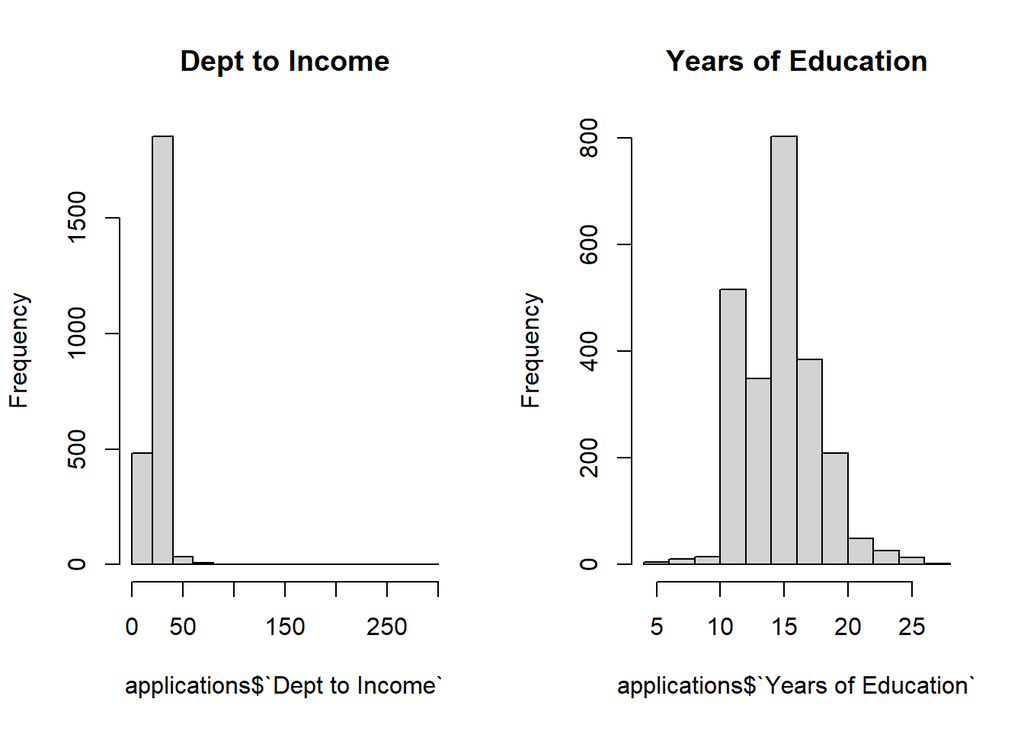

```r
par(mfrow = c(1,2))
hist(applications$`Dept to Income`, main="Dept to Income")
hist(applications$`Years of Education`, main= "Years of Education")
```

```r
par(mfrow = c(1,1))
```

We can see from the histogram for Dept to Income that the raw data does not appear to be normally distributed. We will therefore need to normalize it in some manner. Let’s try removing rows with greater than 100$ DTI which does not make sense.

#### i. Normalize Dept to Income

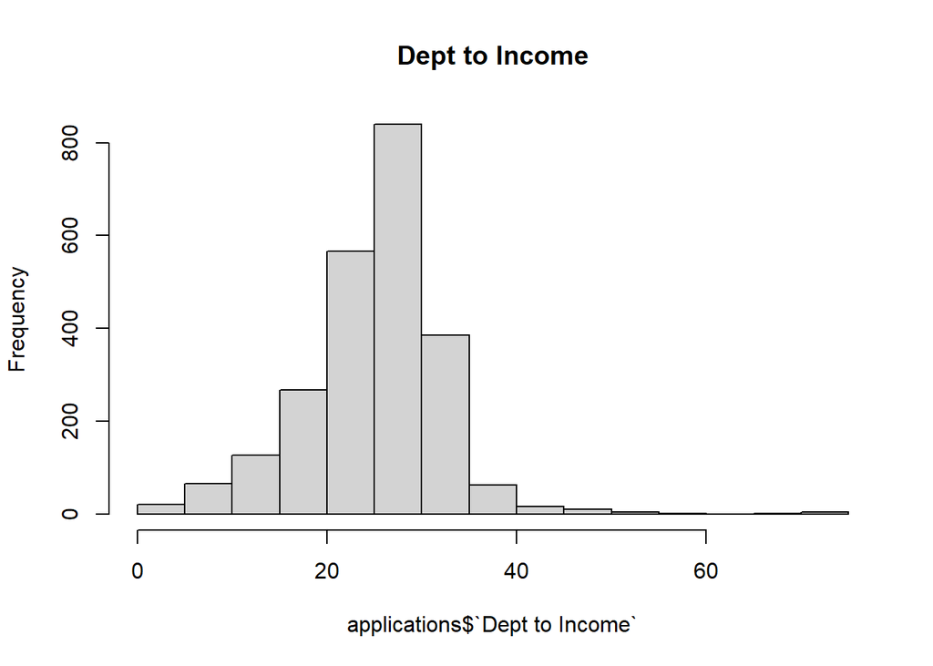

```r
# applications$`Years of Education Norm` <- log(applications$`Years of Education`)
outliers <- c(which(applications$`Dept to Income` > 100))
applications <- applications[-c(which(applications$`Dept to Income` > 100)), ]

hist(applications$`Dept to Income`, main="Dept to Income")
```

Without the outliers, the DTI now appears to be normally distributed so, we will move on.

### c. Frequency Counts by Race

```r
kable(table(applications$Race, applications$'Marital Status', dnn = c('Race', 'Marital Status')))
```

|  | married | unmarried | seperated |
| --- | --- | --- | --- |
| black | 164 | 155 | 20 |
| white | 1279 | 703 | 54 |

```r
kable(table(applications$Race, applications$`Years of Education`, dnn = c('Race', 'Years of Education')))
```

|  | 5 | 6 | 7 | 8 | 9 | 10 | 11 | 12 | 13 | 13.5 | 14 | 15 | 15.5 | 16 | 16.5 | 17 | 18 | 19 | 20 | 21 | 22 | 23 | 24 | 25 | 26 | 27 |
| --- | --- | --- | --- | --- | --- | --- | --- | --- | --- | --- | --- | --- | --- | --- | --- | --- | --- | --- | --- | --- | --- | --- | --- | --- | --- | --- |
| black | 1 | 1 | 3 | 0 | 1 | 3 | 2 | 98 | 12 | 1 | 56 | 24 | 0 | 74 | 1 | 12 | 20 | 8 | 11 | 2 | 2 | 2 | 2 | 1 | 1 | 1 |
| white | 1 | 0 | 2 | 5 | 2 | 9 | 8 | 407 | 74 | 2 | 204 | 57 | 1 | 646 | 2 | 128 | 221 | 86 | 104 | 27 | 18 | 14 | 8 | 7 | 2 | 1 |

```r
kable(table(applications$Race, applications$`Self Employed`, dnn = c('Race', 'Self Employed')))
```

|  | not_self_employed | self_employed |
| --- | --- | --- |
| black | 314 | 25 |
| white | 1787 | 249 |

```r
#table(applications$Race, applications$`Dept to Income`, dnn = c('Race', 'DTI'))
kable(table(applications$Race, applications$`Risk`, dnn = c('Race', 'Risk')))
```

|  | low | med | high |
| --- | --- | --- | --- |
| black | 208 | 123 | 7 |
| white | 1391 | 619 | 23 |

```r
kable(table(applications$Race, applications$`Type of Action Taken`, dnn = c('Race', 'Type of Action')))
```

|  | originated | approved_not_accepted | denied |
| --- | --- | --- | --- |
| black | 233 | 10 | 96 |
| white | 1790 | 60 | 186 |

### d. Histograms of quantitative data columns

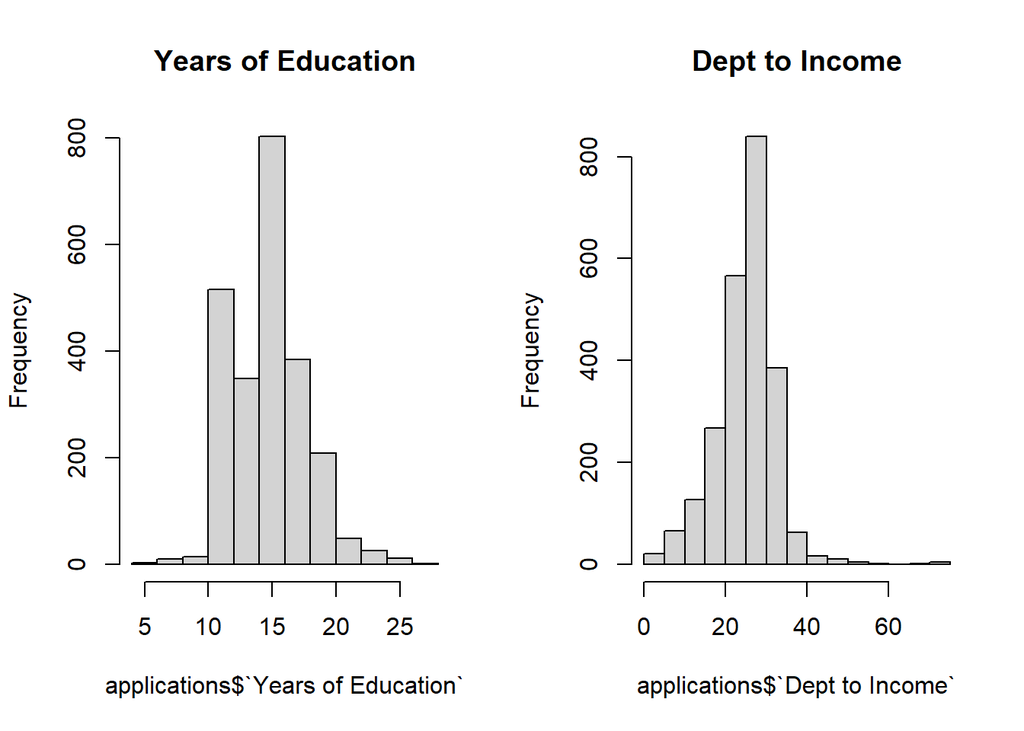

```r
par(mfrow=c(1,2))
hist(applications$`Years of Education`, main = "Years of Education")
hist(applications$`Dept to Income`, main = "Dept to Income")
```

```r
par(mfrow=c(1,1))
```

Here we discuss a representative sample applicant. A representative applicant is married, white, not self-employed, with 15 years of education and a dept to income ratio of 25 making them low risk applicant of which most were approved.

# C. Logistic Regression Model

*“With the full sample, estimate the logistic regression model, where the deny/approve dummy variable is the response variable and the debt-to-income ratio and the race, self-employed, marital status, and education indicator variables are the co-variates. Graph the ROC curve and calculate the AUC. Also, compute the confusion matrix at alternative cut-off levels, and calculate the classifier sensitivity, specificity, the false-positive rate, the false-negative rate, the model accuracy and error rate to confirm they are the same as those produced by R. Provide a written explanation summarizing the findings.”*

### a. Logistic Regression Analysis

Here we run create a logistic regression with response variable being the approved/denied column and the using all other variables as co-variates except for Type of Action Taken which causes the model to not converge.

```r
fit.logit <- glm(Approved ~ Risk + Race +
                  applications$`Self Employed` +
                  applications$`Marital Status` +
                  applications$`Years of Education`,
                data=applications,
                family = 'binomial')
summary(fit.logit)
```

```
##
## Call:
## glm(formula = Approved ~ Risk + Race + applications$`Self Employed` +
##     applications$`Marital Status` + applications$`Years of Education`,
##     family = "binomial", data = applications)
##
## Deviance Residuals:
##     Min       1Q   Median       3Q      Max
## -2.5477   0.3564   0.4160   0.4890   1.4048
##
## Coefficients:
##                                            Estimate Std. Error z value Pr(>|z|)
## (Intercept)                                0.150128   0.376324   0.399 0.689942
## Riskmed                                   -0.340293   0.138743  -2.453 0.014179
## Riskhigh                                  -1.632910   0.400826  -4.074 4.62e-05
## Racewhite                                  1.291184   0.148832   8.675  < 2e-16
## applications$`Self Employed`self_employed -0.480708   0.192526  -2.497 0.012530
## applications$`Marital Status`unmarried    -0.385234   0.135827  -2.836 0.004565
## applications$`Marital Status`seperated    -0.004199   0.369010  -0.011 0.990921
## applications$`Years of Education`          0.080201   0.024061   3.333 0.000858
##
## (Intercept)
## Riskmed                                   *
## Riskhigh                                  ***
## Racewhite                                 ***
## applications$`Self Employed`self_employed *
## applications$`Marital Status`unmarried    **
## applications$`Marital Status`seperated
## applications$`Years of Education`         ***
## ---
## Signif. codes:  0 '***' 0.001 '**' 0.01 '*' 0.05 '.' 0.1 ' ' 1
##
## (Dispersion parameter for binomial family taken to be 1)
##
##     Null deviance: 1717.8  on 2370  degrees of freedom
## Residual deviance: 1589.4  on 2363  degrees of freedom
##   (4 observations deleted due to missingness)
## AIC: 1605.4
##
## Number of Fisher Scoring iterations: 5
```

```r
coef(fit.logit)
```

```
##                               (Intercept)
##                               0.150128487
##                                   Riskmed
##                              -0.340293371
##                                  Riskhigh
##                              -1.632910022
##                                 Racewhite
##                               1.291184421
## applications$`Self Employed`self_employed
##                              -0.480707967
##    applications$`Marital Status`unmarried
##                              -0.385233824
##    applications$`Marital Status`seperated
##                              -0.004198878
##         applications$`Years of Education`
##                               0.080200893
```

We see here that High Risk, Race White and Years of Education, all tested very significant. We will try to hone down our model by trimming out Self Employment and Marital Status on the hunch that they are causing noise.

```r
fit.logit <- glm(Approved ~ Risk + Race + applications$`Years of Education`, data=applications, family = 'binomial')
summary(fit.logit)
```

```
##
## Call:
## glm(formula = Approved ~ Risk + Race + applications$`Years of Education`,
##     family = "binomial", data = applications)
##
## Deviance Residuals:
##     Min       1Q   Median       3Q      Max
## -2.4530   0.3683   0.4177   0.4652   1.5407
##
## Coefficients:
##                                    Estimate Std. Error z value Pr(>|z|)
## (Intercept)                        0.001676   0.370214   0.005  0.99639
## Riskmed                           -0.337213   0.137557  -2.451  0.01423 *
## Riskhigh                          -1.727849   0.399264  -4.328 1.51e-05 ***
## Racewhite                          1.300214   0.146499   8.875  < 2e-16 ***
## applications$`Years of Education`  0.075279   0.023914   3.148  0.00164 **
## ---
## Signif. codes:  0 '***' 0.001 '**' 0.01 '*' 0.05 '.' 0.1 ' ' 1
##
## (Dispersion parameter for binomial family taken to be 1)
##
##     Null deviance: 1717.8  on 2370  degrees of freedom
## Residual deviance: 1603.0  on 2366  degrees of freedom
##   (4 observations deleted due to missingness)
## AIC: 1613
##
## Number of Fisher Scoring iterations: 5
```

```r
coef(fit.logit)
```

```
##                       (Intercept)                           Riskmed
##                       0.001676068                      -0.337212877
##                          Riskhigh                         Racewhite
##                      -1.727848720                       1.300214093
## applications$`Years of Education`
##                       0.075279081
```

### b. Train and Validate a Classifier and then Graph the ROC

```r
set.seed(1234)

train <- sample(nrow(applications), 0.7*nrow(applications))

applications.train <- applications[train,]
applications.validate <- applications[-train,]

applications.train <- na.omit(applications.train)
applications.validate <- na.omit(applications.validate)

table(applications.train$Approved)
```

```
##
##   denied approved
##      199     1459
```

```r
summary(applications.validate$Approved)
```

```
##   denied approved
##       80      633
```

```r
# Fit the model on the trained data with variables from the validation dataframe
fit.logit.trained <- glm(Approved ~ Risk + Race + `Years of Education`, data=applications.train, family = 'binomial')

summary(fit.logit.trained)
```

```
##
## Call:
## glm(formula = Approved ~ Risk + Race + `Years of Education`,
##     family = "binomial", data = applications.train)
##
## Deviance Residuals:
##     Min       1Q   Median       3Q      Max
## -2.4305   0.3757   0.4163   0.4729   1.6228
##
## Coefficients:
##                      Estimate Std. Error z value Pr(>|z|)
## (Intercept)           0.07132    0.44077   0.162   0.8715
## Riskmed              -0.33879    0.16262  -2.083   0.0372 *
## Riskhigh             -1.92985    0.49405  -3.906 9.38e-05 ***
## Racewhite             1.26343    0.17456   7.238 4.56e-13 ***
## `Years of Education`  0.07115    0.02830   2.514   0.0119 *
## ---
## Signif. codes:  0 '***' 0.001 '**' 0.01 '*' 0.05 '.' 0.1 ' ' 1
##
## (Dispersion parameter for binomial family taken to be 1)
##
##     Null deviance: 1216.9  on 1657  degrees of freedom
## Residual deviance: 1135.6  on 1653  degrees of freedom
## AIC: 1145.6
##
## Number of Fisher Scoring iterations: 5
```

```r
probability <- predict(fit.logit.trained, applications.validate, type = 'response')

logit.predicted <- factor(probability > 0.75, levels = c(FALSE,TRUE),
                     labels = c("approved","denied"))

logit.perf <- table(applications.validate$Approved, logit.predicted, dnn = c("Actual","Predicted"))

logit.perf
```

```
##           Predicted
## Actual     approved denied
##   denied         21     59
##   approved       54    579
```

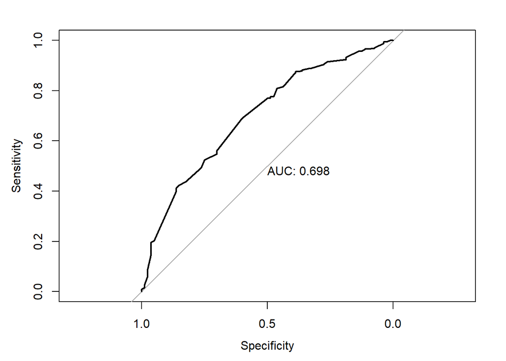

```r
# Graph ROC
applications_roc <- roc(applications.validate$Approved ~ probability, plot = TRUE, print.auc=TRUE)
```

```r
# Calculate Area Under Curve
auc(applications_roc)
```

```
## Area under the curve: 0.6983
```

### c. Find threshold that maximizes the sensitivity and specificity by pulling it from the ROC object.

```r
coords(applications_roc, "best", ret = "threshold")
```

```
##   threshold
## 1 0.8967131
```

```r
coords(applications_roc)
```

```
##    threshold specificity sensitivity
## 1       -Inf      0.0000 1.000000000
## 2  0.4458551      0.0125 1.000000000
## 3  0.5867798      0.0250 0.993680885
## 4  0.6209130      0.0375 0.993680885
## 5  0.6356110      0.0375 0.990521327
## 6  0.6405805      0.0375 0.987361769
## 7  0.6506213      0.0750 0.969984202
## 8  0.6666130      0.0750 0.968404423
## 9  0.6775923      0.1000 0.965244866
## 10 0.6882977      0.1125 0.965244866
## 11 0.7004418      0.1125 0.963665087
## 12 0.7078638      0.1250 0.957345972
## 13 0.7115365      0.1250 0.955766193
## 14 0.7141977      0.1375 0.955766193
```

[output cut: 45 more lines]

```r
# or

threshold <- applications_roc$thresholds[which.max(applications_roc$sensitivities + applications_roc$specificities)]
threshold
```

```
## [1] 0.8967131
```

### d. Use the best threshold

```r
logit.predicted.thresh <- factor(probability > threshold, levels = c(FALSE,TRUE),
                     labels = c("approved","denied"))

logit.perf.thresh <- table(applications.validate$Approved, logit.predicted.thresh, dnn = c("Actual","Predicted"))

logit.perf.thresh
```

```
##           Predicted
## Actual     approved denied
##   denied         48     32
##   approved      196    437
```

The confusion matrix shows that our model had many false negatives. It doesn’t appear to perform well and is much worse than just taking the average and just approving every applicant which will be correct 88% of the time.

### e. Introduce Performance method from ‘R in Action’ to get the sensitivity, specificity, the false-positive rate, the false-negative rate, the model accuracy and error rate.

```r
performance <- function(title, table, n = 4){
  if(!all(dim(table) == c(2,2)))
    stop("Must be a 2 x 2 table")
  tn = table[1,1]
  fp = table[1,2]
  fn = table[2,1]
  tp = table[2,2]
  sensitivity = tp/(tp+fn)
  specificity = tn/(tn+fp)
  ppp = tp/(tp+fp)
  npp = tn/(tn+fp)
  hitrate = (tp+tn)/(tp+tn+fp+fn)
  result <- paste0("----| ", title, " |----", "\nSensitivity = ", round(sensitivity,n),
                   "\nSpecificity = ",round(specificity,n),
                   "\nPositive Predictive Value = ", round(ppp,n),
                   "\nNegative Predictive Value = ", round(npp,n),
                   "\nAccuracy = ", round(hitrate,n), "\n\n")
  cat(result)
}
```

```r
performance("Logit.perf", logit.perf)
```

```
## ----| Logit.perf |----
## Sensitivity = 0.9147
## Specificity = 0.2625
## Positive Predictive Value = 0.9075
## Negative Predictive Value = 0.2625
## Accuracy = 0.8415
```

```r
performance("Logit.perf.thresh", logit.perf.thresh)
```

```
## ----| Logit.perf.thresh |----
## Sensitivity = 0.6904
## Specificity = 0.6
## Positive Predictive Value = 0.9318
## Negative Predictive Value = 0.6
## Accuracy = 0.6802
```

The accuracy of our model was below the 88% average at 84%. The predictive accurracy of the original model was low but the after using the best threshold the predictive accuracy was actually lowered.

# D. Validation Techniques

*“Next, using 10-fold cross validation, estimate a variety of logistic regression models and evaluate their predictive performance across a range of threshold values in each case. The models can (should) include interaction variables and polynomial terms (e.g., quadratic and cubic variables). Of interest is identifying the model and threshold value that yield the smallest average test mis-classification rate; however, you can also calculate model accuracy and the AUC. Document in a table the performance of the various models using the chosen performance measures.”*

### a. Run Gamma-Lasso regression

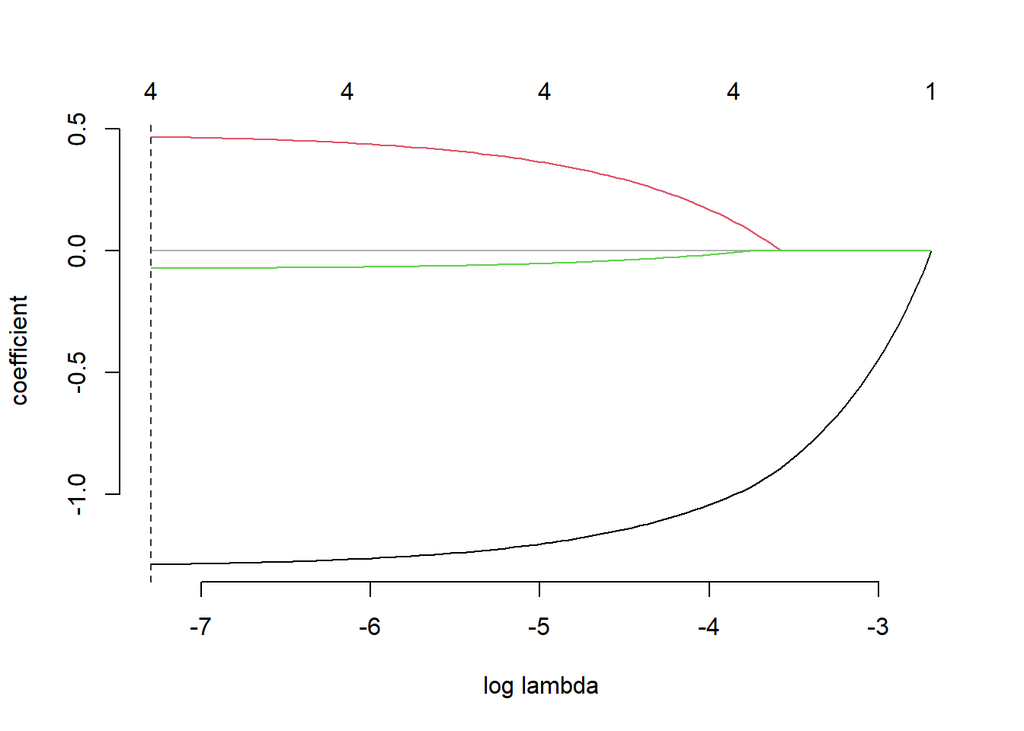

```r
applications <- na.omit(applications)
training_response <- data.matrix(applications$Approved)
training_data_matrix <- data.matrix(applications[ , c('Race','Risk', 'Years of Education')])
result_reg <- gamlr(training_data_matrix, as.factor(training_response),  verb=FALSE, family='binomial')
plot(result_reg)
```

### b. Perform 10 fold cross validation

```r
cv.result_reg <- cv.gamlr(training_data_matrix, as.factor(training_response), verb=TRUE,nfold =10)
```

```
## fold 1,2,3,4,5,6,7,8,9,10,done.
```

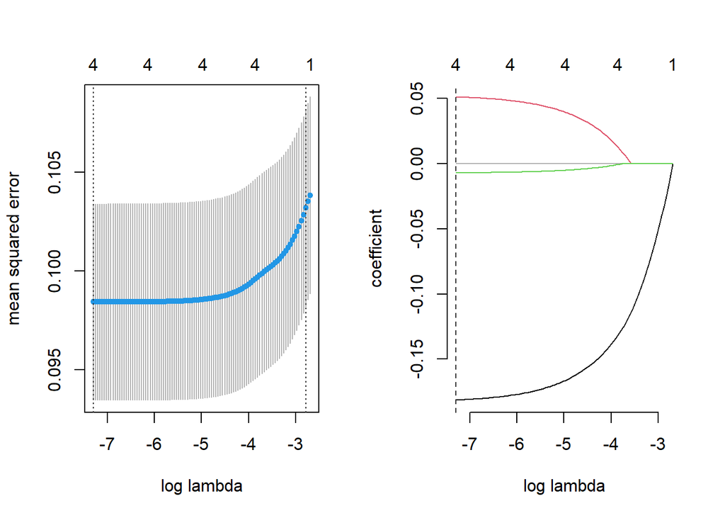

```r
beta1se <- coef(cv.result_reg) ## 1se rule; see ?cv.gamlr
betamin <- coef(cv.result_reg, select="min") ## min cv selection

par(mfrow=c(1,2))
plot(cv.result_reg)
plot(cv.result_reg$gamlr) ## cv.gamlr includes a gamlr object
```

```r
par(mfrow=c(1,2))
```

### c. Compare model selections

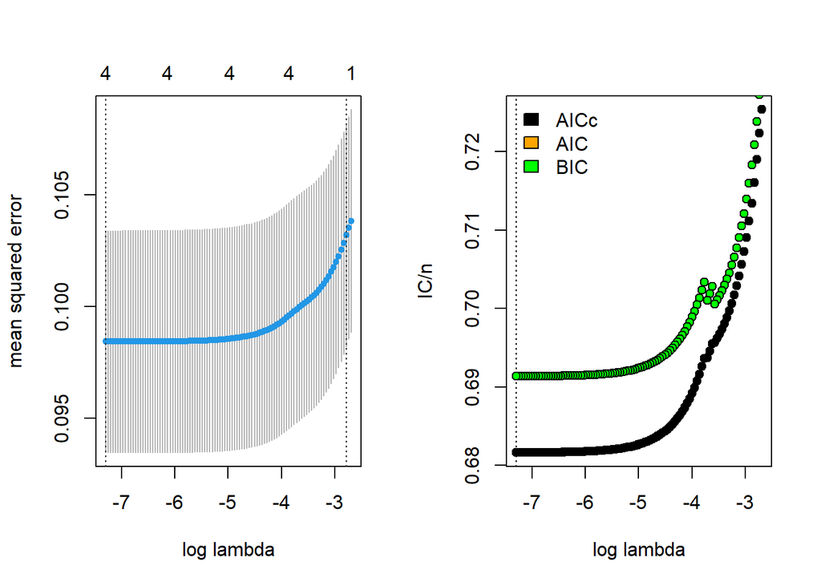

```r
ll <- log(result_reg$lambda) ## the sequence of lambdas
n <- nrow(applications)
par(mfrow=c(1,2))
plot(cv.result_reg)
plot(ll, AIC(result_reg)/n, # scaled by the number of obs (n)
    xlab="log lambda", ylab="IC/n", pch=21, bg="orange")
abline(v=ll[which.min(AIC(result_reg))], col="orange", lty=3)
abline(v=ll[which.min(BIC(result_reg))], col="green", lty=3)
abline(v=ll[which.min(AICc(result_reg))], col="black", lty=3)
points(ll, BIC(result_reg)/n, pch=21, bg="green")
points(ll, AICc(result_reg)/n, pch=21, bg="black")
legend("topleft", bty="n",
    fill=c("black","orange","green"),legend=c("AICc","AIC","BIC"))
```

### d. Perform a stepwise regression.

```r
logit.fit.reduced <- step(fit.logit)
```

```
## Start:  AIC=1612.98
## Approved ~ Risk + Race + applications$`Years of Education`
##
##                                     Df Deviance    AIC
## <none>                                   1603.0 1613.0
## - applications$`Years of Education`  1   1613.2 1621.2
## - Risk                               2   1623.0 1629.0
## - Race                               1   1674.5 1682.5
```

### f. Attempt to use Decision Trees

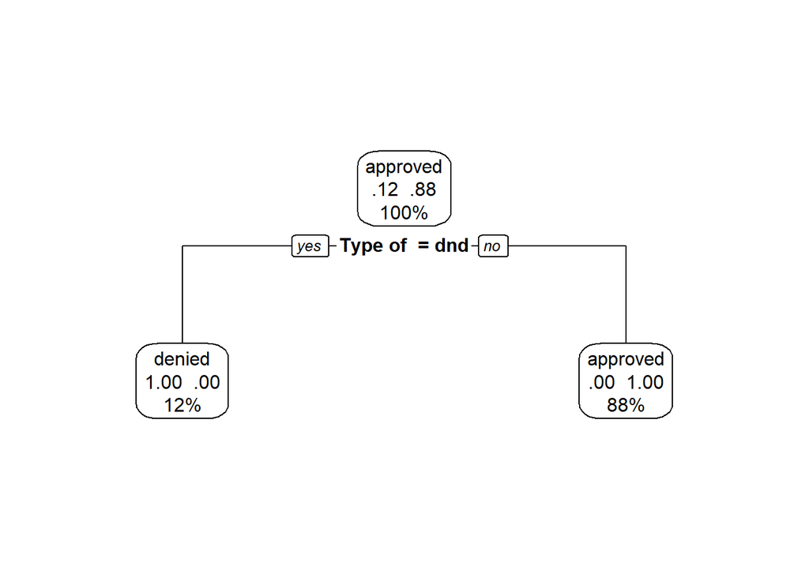

```r
set.seed(1234)

# make the decision tree with the rpart function
dtree <- rpart(Approved ~., data = applications.train, method = 'class', parms = list(split = 'information'), minsplit = 2, minbucket = 1)

prp(dtree, type = 2, extra = 104,fallen.leaves = T)
```

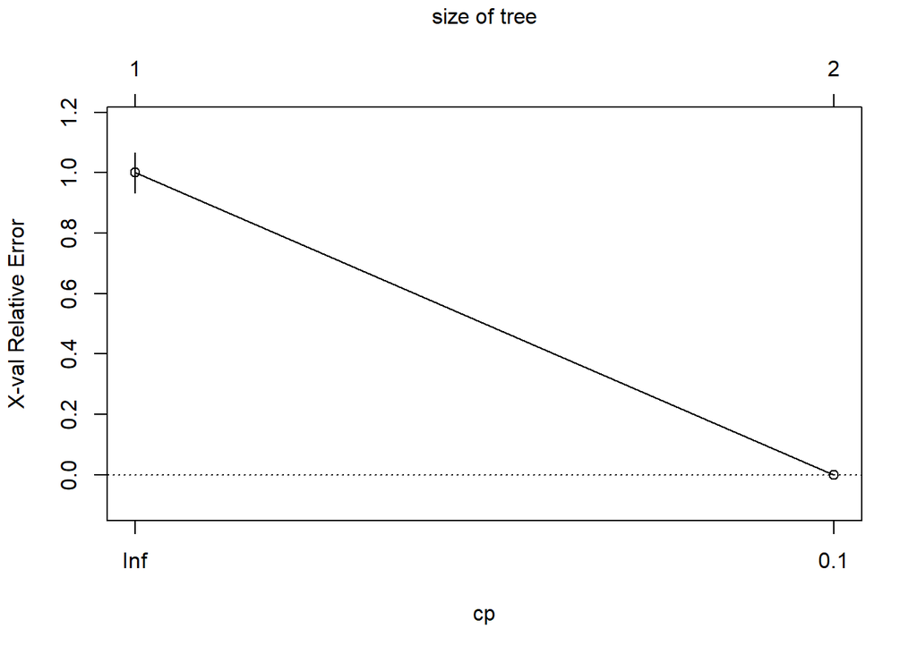

```r
plotcp(dtree)
```

```r
dtree$cptable
```

```
##     CP nsplit rel error xerror       xstd
## 1 1.00      0         1      1 0.06649804
## 2 0.01      1         0      0 0.00000000
```

### g. Try pruning the tree

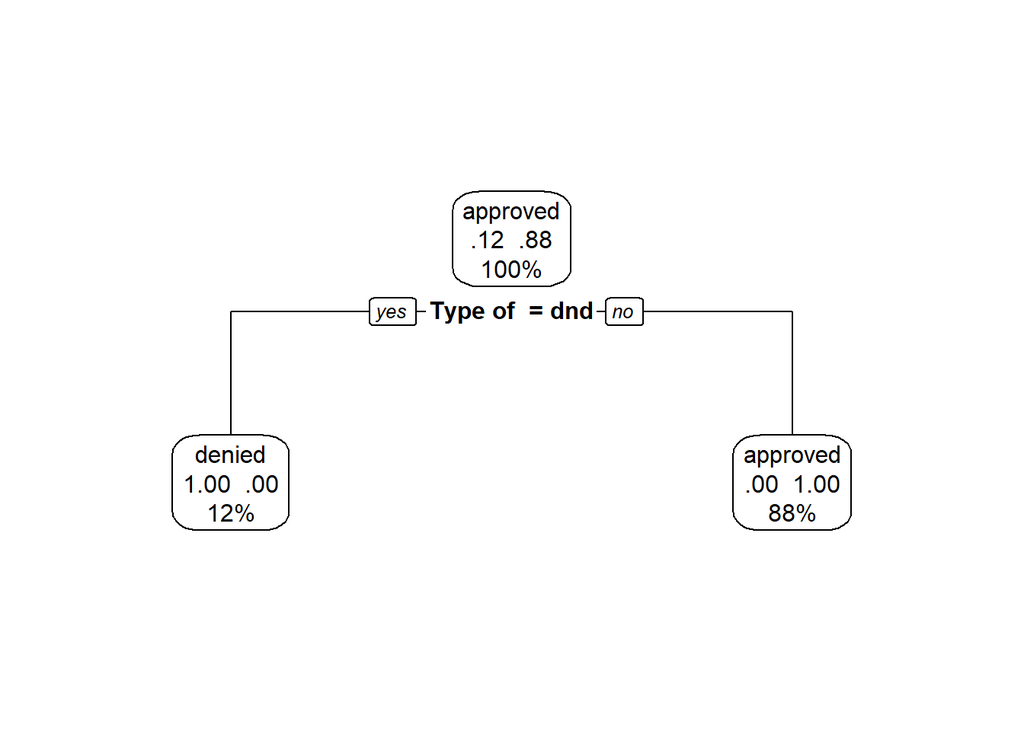

```r
# change the penalty value 'cp' to prune the tree
dtree.pruned <- prune(dtree,cp = 0.18)

prp(dtree.pruned, type = 2, extra = 104,fallen.leaves = T)
```

### h. Try Using a Conditional Inference Tree

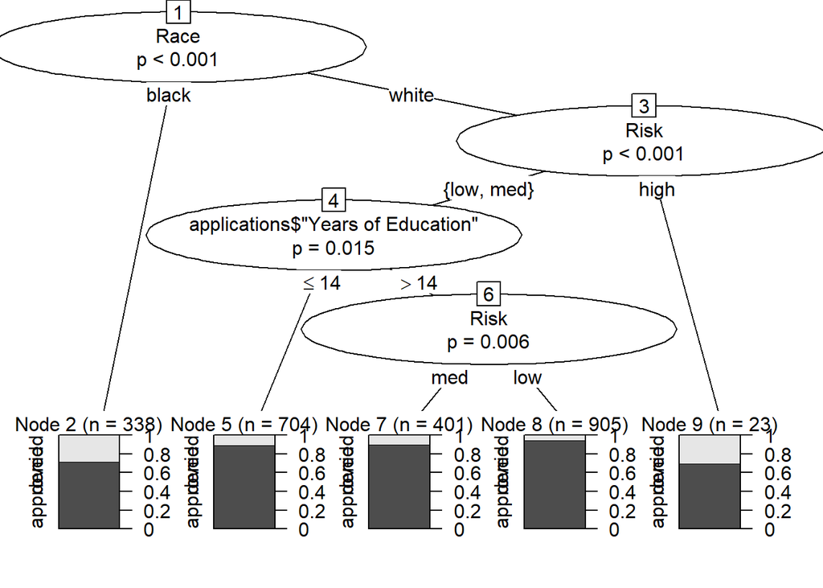

```r
fit.ctree <- ctree(Approved ~ Race + Risk + applications$'Years of Education', data = na.omit(applications))

plot(fit.ctree)
```

### i. Try Using Random Forests

```r
set.seed(1234)

fit.forest <- randomForest(Approved ~ Race + Risk + applications$`Years of Education`, data=applications, na.action=na.roughfix, importance = TRUE)

fit.forest
```

```
##
## Call:
##  randomForest(formula = Approved ~ Race + Risk + applications$`Years of Education`,      data = applications, importance = TRUE, na.action = na.roughfix)
##                Type of random forest: classification
##                      Number of trees: 500
## No. of variables tried at each split: 1
##
##         OOB estimate of  error rate: 11.81%
## Confusion matrix:
##          denied approved  class.error
## denied        0      279 1.0000000000
## approved      1     2091 0.0004780115
```

### j. Try Using Support Vector Machines

```r
set.seed(1234)

fit.svm <- svm(Approved ~ Race + Risk + `Years of Education`, data=na.omit(applications.train))

fit.svm
```

```
##
## Call:
## svm(formula = Approved ~ Race + Risk + `Years of Education`, data = na.omit(applications.train))
##
##
## Parameters:
##    SVM-Type:  C-classification
##  SVM-Kernel:  radial
##        cost:  1
##
## Number of Support Vectors:  424
```

### m. Tuning the SVM model

```r
set.seed(1234)

tuned.svm <- tune.svm(Approved ~., data = na.omit(applications.train),
                  gamma = 10^(-6:1),
                  cost = 10^(-10:10))
tuned.svm
```

```
##
## Parameter tuning of 'svm':
##
## - sampling method: 10-fold cross validation
##
## - best parameters:
##  gamma cost
##   0.01  0.1
##
## - best performance: 0
```

```r
set.seed(1234)

tuned.fit.svm <- svm(Approved ~ Race + Risk + `Years of Education`, data=applications.train, gamma = 0.001, cost = 1)

tuned.fit.svm
```

```
##
## Call:
## svm(formula = Approved ~ Race + Risk + `Years of Education`, data = applications.train,
##     gamma = 0.001, cost = 1)
##
##
## Parameters:
##    SVM-Type:  C-classification
##  SVM-Kernel:  radial
##        cost:  1
##
## Number of Support Vectors:  414
```

# E. Identify the Superior Model

“*Of the competing models that you estimated and thresholds that you evaluated, identify the superior model for classification purposes. Re-estimate the model with the full sample of data. Then, graph the ROC, calculate the AUC, and compute the confusion matrix at the threshold level associated with the minimum average test mis-classification rate . Calculate the classifier sensitivity and specificity, the false-positive rate, the false negative rate, the accuracy, and overall mis-classification rate. How well does your superior model perform relative to the model estimated in C? Explain. Note that to do so you will need to calculate the confusion matrix from the estimated model in C at the threshold level.*”

Here, we will examine the performance of the various models that we created in section D.

### a. Get ROC curve for the reduced model.

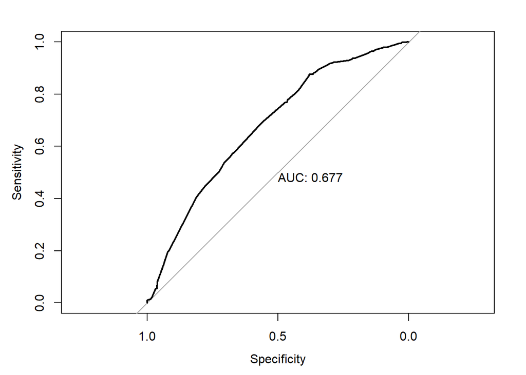

```r
prob_reduced <- predict(logit.fit.reduced, applications, type = 'response')

my_roc_reduced <- roc(applications$Approved ~ prob_reduced, plot = TRUE, print.auc=TRUE)
```

```r
coords(my_roc_reduced, "best", ret="threshold")
```

```
##   threshold
## 1 0.8535358
```

```r
logit.reduced.pred.thresh <- factor(prob_reduced > threshold, levels = c(FALSE,TRUE),
                     labels = c("approved","denied"))

logit.prob_reduced.perf.thresh <- table(applications$Approved, logit.reduced.pred.thresh, dnn = c("Actual","Predicted"))

logit.prob_reduced.perf.thresh
```

```
##           Predicted
## Actual     approved denied
##   denied        132    147
##   approved      484   1608
```

### b. Test the Predictive Accuracy of DTree model

```r
dtree.pred <- predict(dtree, applications.validate,type = "class")

dtree.perf <- table(applications.validate$Approved, dtree.pred, dnn = c("Actual","Predicted"))

dtree.perf
```

```
##           Predicted
## Actual     denied approved
##   denied       80        0
##   approved      0      633
```

### c. Prediction and Performance of the CTree model

```r
ctree.pred <- predict(fit.ctree, na.omit(applications), type = 'response')

ctree.perf <- table(applications$Approved, ctree.pred, dnn = c("Actual","Predicted"))
```

### d. Inspect the variable importance for the Forest model

```r
importance(fit.forest,type = 2)
```

```
##                                   MeanDecreaseGini
## Race                                     19.033168
## Risk                                      5.998029
## applications$`Years of Education`         8.569855
```

### e. Prediction using the Forest model

```r
forest.pred <- predict(fit.forest, applications)

forest.perf <- table(applications$Approved, forest.pred, dnn = c("Actual","Predicted"))

forest.perf
```

```
##           Predicted
## Actual     denied approved
##   denied        0      279
##   approved      0     2092
```

### f. Prediction and Performance of SVM

```r
svm.pred <- predict(fit.svm,na.omit(applications.validate))

svm.perf <- table(na.omit(applications.validate)$Approved, svm.pred, dnn = c("Actual","Predicted"))

svm.perf
```

```
##           Predicted
## Actual     denied approved
##   denied        0       80
##   approved      0      633
```

### g. Prediction and Performance of Tuned SVM Model

```r
tuned.svm.pred <- predict(tuned.fit.svm,na.omit(applications.validate))

tuned.svm.perf <- table(na.omit(applications.validate)$Approved, tuned.svm.pred, dnn = c("Actual","Predicted"))
```

### h. Use the results to Select the Best Model

Performance Metrics for all Models

```r
performance("Logistic", logit.perf)
```

```
## ----| Logistic |----
## Sensitivity = 0.9147
## Specificity = 0.2625
## Positive Predictive Value = 0.9075
## Negative Predictive Value = 0.2625
## Accuracy = 0.8415
```

```r
performance("DTree", dtree.perf)
```

```
## ----| DTree |----
## Sensitivity = 1
## Specificity = 1
## Positive Predictive Value = 1
## Negative Predictive Value = 1
## Accuracy = 1
```

```r
performance("CTree", ctree.perf)
```

```
## ----| CTree |----
## Sensitivity = 1
## Specificity = 0
## Positive Predictive Value = 0.8823
## Negative Predictive Value = 0
## Accuracy = 0.8823
```

```r
performance("Forest", forest.perf)
```

```
## ----| Forest |----
## Sensitivity = 1
## Specificity = 0
## Positive Predictive Value = 0.8823
## Negative Predictive Value = 0
## Accuracy = 0.8823
```

```r
performance("SVM", svm.perf)
```

```
## ----| SVM |----
## Sensitivity = 1
## Specificity = 0
## Positive Predictive Value = 0.8878
## Negative Predictive Value = 0
## Accuracy = 0.8878
```

```r
performance("Tuned SVM", tuned.svm.perf)
```

```
## ----| Tuned SVM |----
## Sensitivity = 1
## Specificity = 0
## Positive Predictive Value = 0.8878
## Negative Predictive Value = 0
## Accuracy = 0.8878
```

# F. Summarize Modeling Efforts

*“Upload an error-free and well-organized copy of your program and a report that summarizes your modeling efforts and the discussion/explanation of your findings from B, C, D, and E. Be certain to include a table describing the results from the various models you evaluated, and be certain to include the estimation results from your superior model estimated with the full dataset.”*

Estimation results from our superior model (SVM) using the full dataset:

```r
superior.svm.pred <- predict(fit.svm,na.omit(applications))

superior.svm.perf <- table(na.omit(applications)$Approved, superior.svm.pred, dnn = c("Actual","Predicted"))

superior.svm.perf
```

```
##           Predicted
## Actual     denied approved
##   denied        0      279
##   approved      0     2092
```

Table of results from the various model that we evaluated.

[output not shown]